# Quiz Practice

```r
library(ggplot2)
theme_set(theme_bw(base_size = 18))
```

## Mediation & Partial Correlations

Remember that both the **Baron & Kenny method** and a test for **partial correlation** can test causal hypotheses. Let’s compare a test with partial correlation to mediation!

### Mediation analysis

**Causal Models**

**IV**: *Coffee* - 20 subjects in each group either had 0 cups, 2 cups, or 4 cups

**DV**: *Performance* - on a stats quiz with 10 problems, 5-89 points

**Possible Mediator 1**: *Number of problems attempted* (hyperactivity)

**Possible Mediator 2**: *Accuracy* - how likely they were to get a problem right if they tried (better success)

```r
d<-read.csv("http://www.stanford.edu/class/psych252/data/caffeine.csv")
# str(d)

d$cups = 0*as.numeric(d$coffee==1) + 2*as.numeric(d$coffee==2) + 4*as.numeric(d$coffee==3)
# table(d$cups)

d = na.omit(d)
```

Cups of Coffee $\longrightarrow$ Hyperactivity $\longrightarrow$ Performance

```r
library(diagram)
```

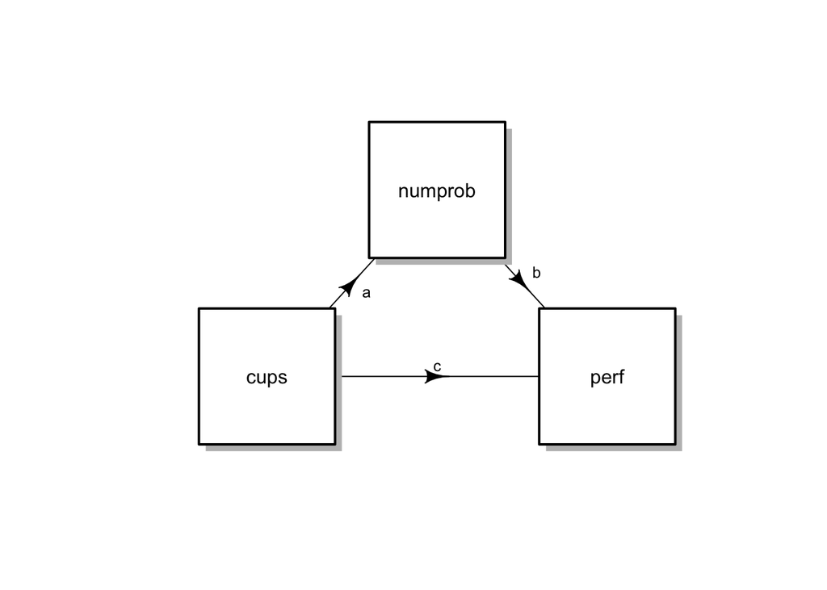

```r
names= list('numprob', 'cups', 'perf')
data_vals = c(0, "a", 0, #X2
              0, 0, 0, #X1
              "b", "c", 0) #Y
M <- matrix(nrow = 3, ncol = 3, byrow = TRUE, data = data_vals)
plotmat(M, pos = c(1, 2), curve = 0, name = names, lwd = 1,
        box.lwd = 2, cex.txt = 0.8, box.type = "square", box.prop = 1.0)
```

What’s the model we don’t need?

*Mediator predicting our DV on its own – lm(y~z)*

#### lm(y ~ x)

```r
model1 = lm(perf~cups, data=d) #c
c_val = model1$coefficients['cups']
```

#### lm(z ~ x)

```r
model2 = lm(numprob~cups, data=d) #a
a_val = model2$coefficients['cups']
se_a_val = summary(model2)$coefficients[2,2] # get SE
```

#### lm(y ~ x + z)

```r
model3 = lm(perf~cups+numprob, data=d) #b and c'
b_val = model3$coefficients['numprob']
cprime_val = model3$coefficients['cups']
se_b_val = summary(model3)$coefficients[3,2]

# note that these are the same!
# cprime_val
# c_val - a_val * b_val
```

#### Sobel test

```r
se_ab <- sqrt(b_val^2*
                se_a_val^2+a_val^2
              *se_b_val^2+se_a_val^2*se_b_val^2)
se_ab # standard error of a*b
```

```
## numprob
##   1.486
```

```r
sobel_stat = a_val*b_val/se_ab; sobel_stat
```

```
##  cups
## 2.034
```

```r
p_s_ab <- pnorm(sobel_stat, lower.tail=F)
p_s_ab # p of ratio of a*b over its s.e.
```

```
##    cups
## 0.02098
```

```r
# c_val
# cprime_val
```

#### How would we interpret this output?

### Partial correlation

Now let’s compare this test of our causal model with a partial correlation test. Partial correlations find the correlation between two variables after removing the effects of other variables.

x = **IV** *(cups of coffee)*

y = **DV** *(performance)*

z = **third variable** *(confounding variable)*

Here, a researcher might wonder **if the effect of cups of coffee on performance still holds, with the effects of hyperactivity removed**. They could use partial correlation to answer this question!

First, we’ll need to find out what our correlations are.

```r
with(d, cor.test(cups,perf)) -> a; print(a)
```

```
##
##  Pearson's product-moment correlation
##
## data:  cups and perf
## t = 2.711, df = 58, p-value = 0.0088
## alternative hypothesis: true correlation is not equal to 0
## 95 percent confidence interval:
##  0.08906 0.54307
## sample estimates:
##    cor
## 0.3354
```

```r
with(d, cor.test(cups,numprob)) -> b; print(b)
```

```
##
##  Pearson's product-moment correlation
##
## data:  cups and numprob
## t = 8.124, df = 58, p-value = 3.789e-11
## alternative hypothesis: true correlation is not equal to 0
## 95 percent confidence interval:
##  0.5838 0.8298
## sample estimates:
##    cor
## 0.7296
```

```r
with(d, cor.test(numprob,perf)) -> c; print(c)
```

```
##
##  Pearson's product-moment correlation
##
## data:  numprob and perf
## t = 3.511, df = 58, p-value = 0.0008722
## alternative hypothesis: true correlation is not equal to 0
## 95 percent confidence interval:
##  0.1843 0.6079
## sample estimates:
##    cor
## 0.4186
```

What’s the formula for a partial correlation?

$\textrm{Partial Correlation }: r(xy.z) = \frac{{r_{xy} - r_{xz} * r_{yz}}}{\sqrt{(1-r_{xz}^2) * (1-r_{yz}^2)}}$

```r
n <- 60
xy<- as.numeric(a$estimate); xy
```

```
## [1] 0.3354
```

```r
xz<- as.numeric(b$estimate); xz
```

```
## [1] 0.7296
```

```r
yz<- as.numeric(c$estimate); yz
```

```
## [1] 0.4186
```

```r
r_xy_z<-(xy-(xz*yz))/(sqrt((1-xz^2)*(1-yz^2))); print(r_xy_z)
```

```
## [1] 0.04826
```

```r
z_fisher = 0.5*log((1+r_xy_z)/(1-r_xy_z)); z_fisher
```

```
## [1] 0.0483
```

```r
2*pnorm(q = z_fisher, mean = 0, sd=sqrt(1/(n-1-3)), lower.tail=F)
```

```
## [1] 0.7178
```

```r
# t2 <- r_xy_z*sqrt((n-3)/(1-r_xy_z^2)); print(t2)
# ptr<-2*pt(t2,n-3, lower.tail=FALSE); print(ptr)

# install.packages('ppcor')
library(ppcor)
print(pcor.test(d$cups, d$perf, d$numprob))
```

```
##   estimate p.value statistic  n gp  Method
## 1  0.04826  0.7153    0.3648 60  1 pearson
```

Let’s do this using `library(psych)`

```r
library(psych)
# ?partial.r
```

For number of problems attempted:

```r
subset(d,select=c('cups','perf','numprob')) -> da
partial.r(da, 1:2, 3)
```

```
## partial correlations
##      cups perf
## cups 1.00 0.05
## perf 0.05 1.00
```

#### Interpret the results!

Since the partial correlation of coffee on performance (controlling for hyperactivity) is not significantly greater than zero, r = 0.05, p > 0.1, hyperactivity may be a mediating variable – we should then run a mediation test, described above!

#### Another way of framing a partial correlation question

What if cups of coffee predicted **both** hyperactivity and performance, but performance and the number of problems weren’t related?

In other words, a researcher asking this question might think: **there’s not a causal link between hyperactivity and performance**; really cups of coffee causes **both** hyperactivity and performance.

In other words, we might want to know the effect of `numprob` on `perf`, controlling for `cups`. If the partial correlation (the correlation between `numprob` and `perf`, partialling out `cups`) is zero, then the original “hyperactivity predicts performance” correlation is probably spurious.

We are interested in this model:

#### Cups of Coffee $\longrightarrow$ Hyperactivity

$\downarrow$

#### Compute the correlations

```r
cor(na.omit(d[,c('cups', 'numprob', 'perf')]))
```

```
##           cups numprob   perf
## cups    1.0000  0.7296 0.3354
## numprob 0.7296  1.0000 0.4186
## perf    0.3354  0.4186 1.0000
```

```r
n <- 60
xy<- 0.4186321
xz<- 0.7295802
yz<- 0.3354014

r_xy_z<-(xy-(xz*yz))/(sqrt((1-xz^2)*(1-yz^2))); print(r_xy_z)
```

```
## [1] 0.27
```

```r
# t2 <- sqrt(((n-3)*r_xy_z^2)/(1-r_xy_z^2)); print(t2)
# t2 <- r_xy_z * sqrt(((n-3))/(1-r_xy_z^2)); print(t2)
# ptr<-2*pt(t2,n-3, lower.tail=FALSE); print(ptr)

print(pcor.test(d$numprob, d$perf, d$cups))
```

```
##   estimate p.value statistic  n gp  Method
## 1     0.27 0.03428     2.117 60  1 pearson
```

```r
z_fisher = 0.5*log((1+r_xy_z)/(1-r_xy_z)); z_fisher
```

```
## [1] 0.2768
```

```r
2*pnorm(q = z_fisher, mean = 0, sd=sqrt(1/(n-1-3)), lower.tail=F)
```

```
## [1] 0.03831
```

#### Interpret

Here, since the partial correlation of hyperactivity on performance, when partialling out cups of coffee, is significantly greater than zero, r=0.27, p < 0.05, this suggests that there is some relationship between hyperactivity and performance that isn’t explained by coffee, and therefore, that the model above does not appropriately capture the relationships between the variables.